# **Introduction to Natural Language Processing (NLP)** - NER & Sentiment Analysis

**Duke Fuqua Master of Quantitative Management**

**Code by AJ Overton**

If you have participated in previous MQM ML workshops, you will have been introduced to the principles of machine learning in PyTorch, constructing simple multi-layer perceptrons (MLP) and convolutional neural networks (CNN) for specific tasks. You will also be familiar with the idea of pre-defined or pre-trained models like ResNet, VGG16, U-Net, and more.

In this session, we will focus on applied NLP using higher-level utility functions that abstract-away some of the nuances of both data preparation and model specification using the [spaCy](https://spacy.io/) Python package. Spacy delivers both [speed and near state-of-the-art performance](https://spacy.io/usage/facts-figures#benchmarks) on many common NLP tasks. SpaCy's model architectures are written in [Thinc](https://thinc.ai/), another module that allows easy integration between Tensorflow, PyTorch, and MLMix. While defining neural nets is not the focus of today's discussion, an example can be found [here](https://www.kaggle.com/atulanandjha/bert-testing-on-imdb-dataset-extensive-tutorial). I hope the examples and recipes we will discuss peak your interest and encourage you to dig deeper.

As you have likedly ascertained, NLP applications are complex. Common considerations and applications include:

- **Sentence boundary detection**
- **Tokenization**, splitting text into individual words of punctuation
- **Lemmmatization**, converts words to their root form (i.e., went -> go)
- **Vectorization**, assigning numerical representations to represent similarities between like words
- **Named Entity Recognition (NER)**, detection of things like people, places, and products
- **Token/Entity Disambiguation**, how NL-systems differentiate 'go' as verb, board game, or programming language
- **Sentiment Analysis**
- **Similarity Metrics**

For additional information, see the [spaCy tutorials](https://course.spacy.io/en). Let's get started.

# **1. Motivating Example with NER**

```python
!pip install spacy==3.2
!python -m spacy download en_core_web_sm
!python -m spacy download en_core_web_md
!unzip /content/mqm_nlp.zip

#!pip install -U spacy[cuda100]
#!pip install "cupy-cuda110<8.0.0"
```

[output not shown]

```python
import spacy, pandas as pd
from spacy import displacy
```

```python
nlp = spacy.load("en_core_web_sm")

# Process whole documents
text = ("Amazon and Google have each annonced 20:1 stock splits to occur in June 2022.")
doc = nlp(text)

displacy.render(doc, style="ent", jupyter=True)
```

Amazon ORG and Google ORG have each annonced 20:1 CARDINAL stock splits to occur in June 2022 DATE .

It is not immediately apparent looking at the code, but under the hood, this code is running 5 to 6 different models to segment sentences and words; identify linguistic dependencies; vectorize text for semantic meaning; identify entities; and more. We can have a look at whats under the hood for a given pipeline with the following:

```
for p in nlp.pipeline:
  print(p)

('tok2vec', <spacy.pipeline.tok2vec.Tok2Vec object at 0x7f8a7d88d7c0>)
('tagger', <spacy.pipeline.tagger.Tagger object at 0x7f8a7d88dde0>)
('parser', <spacy.pipeline.dep_parser.DependencyParser object at 0x7f8a756d6ed0>)
('attribute_ruler', <spacy.pipeline.attributeruler.AttributeRuler object at 0x7f8a78981f00>)
('lemmatizer', <spacy.lang.en.lemmatizer.EnglishLemmatizer object at 0x7f8a78869230>)
('ner', <spacy.pipeline.ner.EntityRecognizer object at 0x7f8a756d6f50>)
```

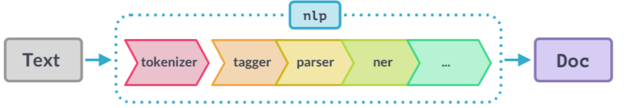

## 1.1 Tokenized Text

```python
print([t for t in doc])
```

[output not shown]

```python
dir(spacy.tokens.token.Token)
```

```python
for t in doc:
  print(t.idx, '\t', t.text, '\t', t.pos_, '\t', t.tag_, '\t', t.dep_, '\t', t.ent_type_)
```

[output not shown]

```python
displacy.render(doc, style="dep", jupyter=True)
```

[figure not shown]

## 1.2 Entity Linking

```python
nlp = spacy.load("en_core_web_sm")

# Process whole documents
text = ("Amazon and Google have each annonced 20:1 stock splits to occur in June 2022.")
doc = nlp(text)

displacy.render(doc, style="ent", jupyter=True)
```

Amazon ORG and Google ORG have each annonced 20:1 CARDINAL stock splits to occur in June 2022 DATE .

```python
print([e for e in doc.ents])
```

[output not shown]

```python
for e in doc.ents:
    print(e.text, e.label_, spacy.explain(e.label_))
```

```
Amazon ORG Companies, agencies, institutions, etc.
Google ORG Companies, agencies, institutions, etc.
20:1 CARDINAL Numerals that do not fall under another type
June 2022 DATE Absolute or relative dates or periods
```

```python
print(nlp.entity.labels)
```

```python
for e in doc.ents:
    pass

dir(e)
```

```python
for e in nlp.entity.labels:
  print(e, spacy.explain(e))
```

## 1.3. Refining an NER System

Let's expand our existing example and look at a collection of texts. In this example, we will see that our NER model is good, but not perfect. Can you identify the issues?

```python
nlp = spacy.load("en_core_web_sm")

HEADLINES = (
    "Amazon and Google have each annonced 20:1 stock splits to occur in June 2022.",
    "Ford is pushing back deliveries to late May due to continuing chip shortage.",
    "Deutsche Bank reverses course on Russia, says it is unwinding business there after Ukraine invasion"
    "Costco memberships may cost more this summer",
    "Apple's new MacBook Air and 13-inch MacBook Pro with M2 processor coming later this summer.",
    "Tesla and Ford are delaying production due to supply-chain shortages."
)

# ---------------------------------
# ---      YOUR CODE HERE       ---
# ---------------------------------
for doc in nlp.pipe(HEADLINES):
  displacy.render(doc, style="ent", jupyter=True)
```

Amazon ORG and Google ORG have each annonced 20:1 CARDINAL stock splits to occur in June 2022 DATE .

Ford ORG is pushing back deliveries to late May due to continuing chip shortage.

Deutsche Bank ORG reverses course on Russia GPE , says it is unwinding business there after Ukraine GPE invasionCostco memberships may cost more this summer DATE

Apple ORG 's new MacBook Air ORG and 13-inch QUANTITY MacBook Pro PERSON with M2 PERSON processor coming later this summer DATE .

Tesla and Ford ORG are delaying production due to supply-chain shortages.

Now that we have observed the potential issues with our existing NER model, let's see if we can refine our code by introducing a few new training samples. We will use the following code recipe to update our NER model components. While we will not cover every facet of the code below, the big thing to notice is the format of the new training data. SpaCy requires a LIST of 2-element TUPLES, where the first element is the text and the second element is a dictionary. The dictionary is a key-value pair, where the KEY is 'entities' and the value is a list of tuples with the following format:

- item 1: start position of a new entity
- item 2: end position of a new entity
- item 3: user-defined types of the new entity

```
ner = nlp.get_pipe("ner")
ner.add_label("<new-entity-name>")
```

There is a [great spaCy format annotater](http://agateteam.org/spacynerannotate/) that can be used to help label new data.

```python
import random
from spacy.util import minibatch, compounding
from spacy.training import Example

nlp = spacy.load("en_core_web_sm")

TRAINING_SAMPLES =[ ("Two US senators have raised concerns about Tesla's driving systems", {"entities": [(43, 48, "ORG")]}),
                    ("Elon Musk in the CEO of Tesla and SpaceX", {"entities": [(24, 29, "ORG"), (34, 40, "ORG")]}),
                    ("Rumors are circulating about the potential MacBook Pro 2022", {"entities": [(43,54,"PRODUCT")]}),
                   ]

ignore_pipes = [pipe for pipe in nlp.pipe_names if pipe!="ner"]
with nlp.disable_pipes(*ignore_pipes):
  for itr in range(5):
    random.shuffle(TRAINING_SAMPLES)
    losses = {}
    batches = minibatch(TRAINING_SAMPLES, size=compounding(4.0, 32.0, 1.001))
    for batch in batches:
      texts, annotations = zip(*batch)

      example = []
      for i in range(len(texts)):
        doc = nlp.make_doc(texts[i])
        example.append(Example.from_dict(doc, annotations[i]))

      nlp.update(example, drop=0.2, losses=losses)
```

```python
for doc in nlp.pipe(HEADLINES):
  displacy.render(doc, style="ent", jupyter=True)
```

Amazon ORG and Google ORG have each annonced 20:1 CARDINAL stock splits to occur in June 2022 DATE .

Ford ORG is pushing back deliveries to late May due to continuing chip shortage.

Deutsche Bank ORG reverses course on Russia GPE , says it is unwinding business there after Ukraine GPE invasionCostco memberships may cost more this summer DATE

Apple ORG 's new MacBook Air PRODUCT and 13-inch QUANTITY MacBook Pro PRODUCT with M2 processor coming later this summer DATE .

Tesla ORG and Ford ORG are delaying production due to supply-chain shortages.

The prior example involves training our model on specific cases of interest, but let's have a look at one of spaCy's models (`en_core_web_md`) which has been trained on a larger corpus of text

```python
nlp = spacy.load("en_core_web_md")

# ---------------------------------
# ---      YOUR CODE HERE       ---
# ---------------------------------
for doc in nlp.pipe(HEADLINES):
  displacy.render(doc, style="ent", jupyter=True)
```

Amazon ORG and Google ORG have each annonced 20:1 CARDINAL stock splits to occur in June 2022 DATE .

Ford ORG is pushing back deliveries to late May DATE due to continuing chip shortage.

Deutsche Bank ORG reverses course on Russia GPE , says it is unwinding business there after Ukraine GPE invasionCostco memberships may cost more this summer DATE

Apple ORG 's new MacBook Air PRODUCT and 13-inch QUANTITY MacBook Pro PRODUCT with M2 processor coming later this summer DATE .

Tesla ORG and Ford ORG are delaying production due to supply-chain shortages.

## 1.4 Automated Document Retrieval

One of the great advantages of domain-specific NER models is the ability to quickly identify relevant texts from a large corpus of text. Imagine reading 1000's of news headlines to identify all that relate to Ford as a company. Can we identify only these documents from our `HEADLINES`?

```python
ford_docs = []
for doc in nlp.pipe(HEADLINES):
  for e in doc.ents:
    if e.text=='Ford' and e.label_=='ORG':
      ford_docs.append(doc.text)
      continue

print(ford_docs)
```

```
['Ford is pushing back deliveries to late May due to continuing chip shortage.', 'Tesla and Ford are delaying production due to supply-chain shortages.']
```

# **2. Sentiment Analysis**

In this next example, we will be looking at text classification, specifically, sentiment analysis. In its simplest form, sentiment analysis generally refers to binary classification reflecting either positive or negative attitudes within a text. You might think of this as akin to the binary classification tasks from earlier MQM ML sessions on logistic regression with MLP. The difference here is that the input is text rather than numbers, at least initially. Other forms of sentiment analysis may include

- more granular sentiment (e.g., on a 5-point likert scale)
- intent analysis
- emotion detection

We will also be using spaCy's [pre-specified model architectures](https://spacy.io/api/textcategorizer), command line interface ([CLI](https://spacy.io/api/cli)), and dataset specification for text classification.

Let's first get started by downloading the IMBD datasets.

## 2.1 Downloading the IMDB Dataset

```python
!pip install spacy==3.2
!python -m spacy download en_core_web_md
!wget https://ai.stanford.edu/~amaas/data/sentiment/aclImdb_v1.tar.gz
!tar -xvf "aclImdb_v1.tar.gz"
```

```python
import os, random, spacy

def load_imdb(path):

  out = []
  for fn in os.listdir(path):
    with open('{path}/{fn}'.format(path=path, fn=fn)) as f:
      text = f.read().replace("<br />", "\n\n").strip()
      out.append((text, path[-3:]))

  return out

# ---------------------------------
# ---      YOUR CODE HERE       ---
# ---------------------------------

train = load_imdb('./aclImdb/train/pos') + load_imdb('./aclImdb/train/neg')
test  = load_imdb('./aclImdb/test/pos') + load_imdb('./aclImdb/test/neg')

random.seed(123)
random.shuffle(train)
random.shuffle(test)
```

## 2.2 Specifying the spaCy Data Format

As we saw in our earlier NER example, spaCy requires a specific document structure to comply with its pre-built model architectures. For this example, we will be using the spaCy [DocBin](https://spacy.io/api/docbin) class to assign the text and a boolean (i.e., TRUE or FALSE) indicator for each of the labels that we wish to train. Note that labels may be either mutually-exclusive or not. In this example, we will be using the labels 'positive' and 'negative', which are mutually exclusive.

```python
from spacy.tokens import DocBin

nlp = spacy.load("en_core_web_md")

def create_spacy_data(data, out_path):
  docs = []
  for doc, label in nlp.pipe(data, as_tuples=True):
    doc.cats['positive'] = 'pos'==label
    doc.cats['negative'] = 'neg'==label
    docs.append(doc)

  doc_bin = DocBin(docs=docs)
  doc_bin.to_disk(out_path)

create_spacy_data(train[:5000],  './train.spacy')
create_spacy_data(train[-5000:], './valid.spacy')
```

## 2.3 Training a spaCy TextCat Model

After generating the spaCy-compliant binary document files, we will use the [spaCy config-file generator](https://spacy.io/usage/training) to specify the default text classification architecture. With only a couple of modifications, we will then be able to instruct spaCy to train our model via the CLI. After selecting the desired options, we will copy-paste the generated text called base_config.cfg. For purposes of this course, this has been completed.

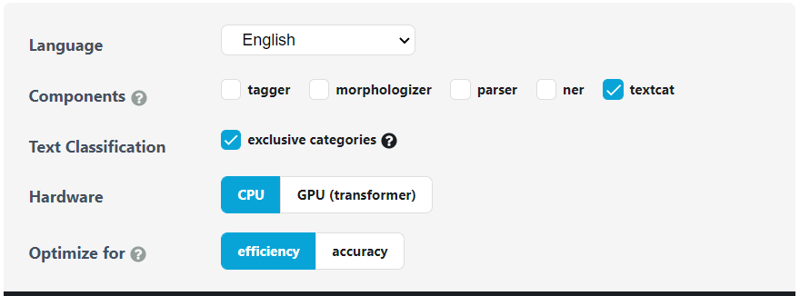

Once the base_config.cfg has been generated, open the file and change

```
[paths]
train = null
dev = null
```

to

```
[paths]
train = "./train.spacy"
dev = "./valid.spacy"
```

```python
!python -m spacy init fill-config ./base_config.cfg ./config.cfg
```

```
✔ Auto-filled config with all values
✔ Saved config
config.cfg
You can now add your data and train your pipeline:
python -m spacy train config.cfg --paths.train ./train.spacy --paths.dev ./dev.spacy
```

```python
!python -m spacy train config.cfg --output ./trained_textcat_model
```

```
✔ Created output directory: trained_textcat_model
ℹ Saving to output directory: trained_textcat_model
ℹ Using CPU

=========================== Initializing pipeline ===========================
[2022-03-15 02:08:44,277] [INFO] Set up nlp object from config
[2022-03-15 02:08:44,288] [INFO] Pipeline: ['textcat']
[2022-03-15 02:08:44,292] [INFO] Created vocabulary
[2022-03-15 02:08:44,294] [INFO] Finished initializing nlp object
[2022-03-15 02:09:09,830] [INFO] Initialized pipeline components: ['textcat']
✔ Initialized pipeline

============================= Training pipeline =============================
ℹ Pipeline: ['textcat']
ℹ Initial learn rate: 0.001
E    #       LOSS TEXTCAT  CATS_SCORE  SCORE
---  ------  ------------  ----------  ------
  0       0          0.50       33.57    0.34
  0     200        128.23       57.65    0.58
  0     400         93.70       74.00    0.74
  0     600         57.27       74.79    0.75
  0     800         68.66       79.68    0.80
  0    1000         53.52       78.81    0.79
  0    1200         64.78       81.07    0.81
  0    1400         56.40       83.76    0.84
  0    1600         53.85       84.26    0.84
  0    1800         59.09       74.76    0.75
  0    2000         53.38       83.79    0.84
  0    2200         46.79       85.54    0.86
  0    2400         53.10       84.38    0.84
  0    2600         39.76       85.44    0.85
  0    2800         29.67       82.49    0.82
  0    3000         40.25       83.60    0.84
  0    3200         35.73       83.14    0.83
  0    3400         32.13       80.78    0.81
  0    3600         18.41       83.78    0.84
  0    3800         15.91       86.65    0.87
  1    4000          1.52       86.68    0.87
  1    4200          3.11       86.26    0.86
  1    4400          8.24       85.77    0.86
  1    4600          5.70       85.97    0.86
  1    4800          7.15       85.21    0.85
  1    5000          7.05       85.17    0.85
  1    5200          4.36       85.80    0.86
  1    5400          2.21       85.85    0.86
  2    5600          1.50       84.39    0.84
✔ Saved pipeline to output directory
trained_textcat_model/model-last
```

Now, let's evaluate our model.

```python
from sklearn.metrics import classification_report

nlp = spacy.load("./trained_textcat_model/model-best")

y_true = []
y_pred = []
for text, label in test[:1000]:
  y_true.append(label)
  if nlp(text).cats['positive']>0.5:
    y_pred.append('pos')
  else:
    y_pred.append('neg')

print(classification_report(y_true, y_pred))
```

```
              precision    recall  f1-score   support

         neg       0.84      0.87      0.86       505
         pos       0.87      0.84      0.85       495

    accuracy                           0.85      1000
   macro avg       0.86      0.85      0.85      1000
weighted avg       0.86      0.85      0.85      1000
```

```python
nlp = spacy.load("./trained_textcat_model/model-best")

tp=fp=fn=tn=0
for text, label in test[:1000]:
  pos = nlp(text).cats['positive']>0.5
  if pos & (label=='pos'):
    tp += 1
  elif pos & (label=='neg'):
    fp += 1
  elif ~pos & (label=='pos'):
    fn += 1
  else:
    tn += 1

print('True positive:', tp , round(100*tp/(tp+fn),2))
print('True negative:', tn , round(100*tn/(tn+fp),2))
print('False positive:', fp, round(100*fp/(fp+tn),2))
print('False negative:', fn, round(100*fn/(fn+tp),2))
```

```
True positive: 414 83.64
True negative: 441 87.33
False positive: 64 12.67
False negative: 81 16.36
```

```python
!zip -r ./mqm_nlp.zip ./train.spacy ./valid.spacy ./base_config.cfg ./config.cfg ./trained_textcat_model/
```

[output not shown]

```python
!jupyter nbconvert --to html /PATH/TO/YOUR/NOTEBOOKFILE.ipynb
```